# My Simple Logistic Regression

### Research Question

Parking Services tasked me with evaluating the viability of increasing the current permit allocation. To assess this, I examined the maximum capacity utilized in each zone and conducted a t-test to determine whether the observed maximum capacity falls below 95%.

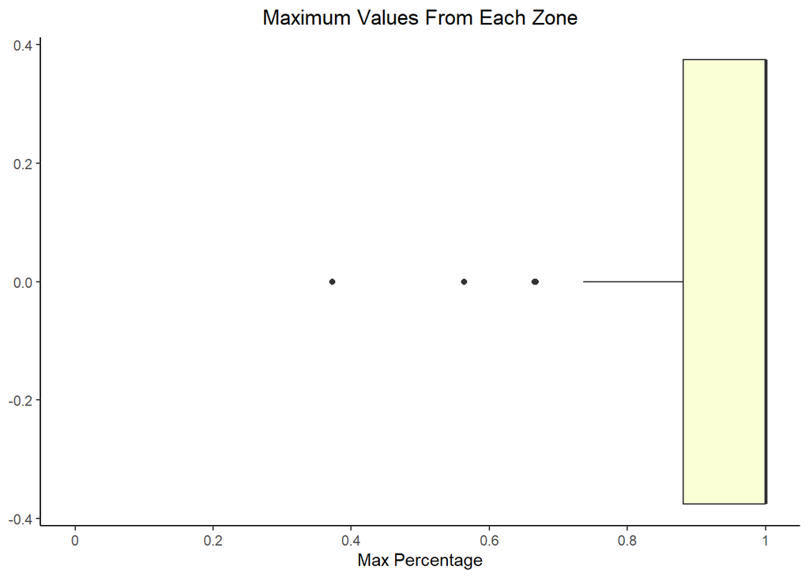

```r
ggplot(parking, aes(x = max)) +
  geom_boxplot(fill = "#FBFFD6") +
  labs(title = "Maximum Values From Each Zone", x = "Max Percentage") +
  theme_classic() +
  theme(
    plot.title = element_text(hjust = 0.5)
  ) +
  scale_x_continuous(limits = c(0, 1), breaks = seq(0, 1, by = 0.2), labels = function(x) round(x, 1))
```

## Analysis

### Check assumptions

The distribution of means can be assumed to be normal since the sample size is greater than 30(52). In other words, the outliers in the data should not affect our results.

### Hypothesis

Our test will be to see if the actual average maximum occupancy of student parking on campus is less than 95%. So our alternative hypothesis uses a less than symbol to convey that question.

$$H_0 = .95$$
$$H_a < .95$$
$$\alpha = .05$$

### T-Test Results

```r
test <- t.test(parking$max, mu = .95, alternative = "less", conf.level = 0.95)
pander(test)
```

One Sample t-test: `parking$max`

| Test statistic | df | P value | Alternative hypothesis | mean of x |
| --- | --- | --- | --- | --- |
| -1.345 | 51 | 0.09232 | less | 0.9257 |

```r
parking %>%
  group_by(Semester) %>%
  summarise(`Average Maximum Occupancy` = mean(max)) %>%
  filter(Semester %in% c("Fall 2019", "Winter 2020", "Fall 2021")) %>%
  arrange(match(Semester, c("Fall 2019", "Winter 2020", "Fall 2021"))) %>%
  pander::pander()
```

| Semester | Average Maximum Occupancy |
| --- | --- |
| Fall 2019 | 0.9562 |
| Winter 2020 | 0.9705 |
| Fall 2021 | 0.8547 |